# Weight Lifting ML Exercise

Michael Becker

May 14, 2020

## Executive Summary

The report below applies a gradient boosting machine (GBM) model to aid in the classification of sensor data taken during unilateral bicep curls. These data, provided by Velloso, Bulling, Gellersen, Ugulino, & Fuks (2013), were collected from 6 participants performing 10 repetitions of the bicep curl in one of five ways. Using a subset of the measures provided, the model trained here and cross-validated using k-folds (k=10) achieves an average in-sample accuracy of 99.48% and thus likely performs similarly in the test set of 20 activity observations. Areas of misclassification and possible explanations for the misclassification are discussed.

## Data

The data in this report represent on-body sensor information taken from six healthy male participants between the ages of 20-28 who were asked to perform one set of 10 repetitions of the unilateral dumbbell biceps curl in five different fashions:

1. Exactly according to specifications
2. Throwing the elbows to the side
3. Lifting the dumbbell only halfway
4. Lowering the dumbbell only halfway, and
5. Throwing the hips to the front.

The sensor information included in the data set include gyroscopic measurements, acceleration, pitch, roll, and yaw for the sensor packages embedded in devices on the participant’s belt, (upper) arm, forearm, and dumbbell. In addition, start and end times were recorded for each observation. Finally, these data are divided into a training set consisting of 19622 observations and a test set of 20 observations resulting in a total sample size of 19642. Below I delineate the dimensions of the training and test datasets as well as the distribution of the observations by outcome class.

```
## [1] 19622   160
```

```
## [1]  20 160
```

```
##
##    A    B    C    D    E
## 5580 3797 3422 3216 3607
```

## Model Building Strategy

Briefly, while there will be variation within and across participant for each class (1-5) due to fatigue, imperfect repetition, and other sources of random variation, there should be far greater systematic variation when looking across classes and this will facilitiat the classification strategy.

```r
#Setting up the cross-validation
train_control<- trainControl(method = "cv", number = 10)
```

```r
#running the model - this includes the X, Y, and Z gyro, acceleration, pitch, roll, and timestamp for all
model <- train(classe~gyros_belt_x + gyros_belt_y + gyros_belt_z + ##belt
                     accel_belt_x + accel_belt_y + accel_belt_z + ##belt
                     pitch_belt + roll_belt + yaw_belt + ##belt
                     roll_arm + pitch_arm + yaw_arm + ##arms
                     accel_arm_x + accel_arm_y + accel_arm_z + ##arms
                     roll_dumbbell + pitch_dumbbell + yaw_dumbbell + ##dumbbell
                     gyros_dumbbell_x + gyros_dumbbell_y + gyros_dumbbell_z + ##dumbbell
                     accel_dumbbell_x + accel_dumbbell_y + accel_dumbbell_z + ##dumbbell
                     gyros_forearm_x + gyros_forearm_y + gyros_forearm_z + ##forearms
                     accel_forearm_x + accel_forearm_y + accel_forearm_z + ##forearms
                     raw_timestamp_part_1 + raw_timestamp_part_2           ##Timestamps
                        , trControl=train_control ,method = "gbm", data = training)
```

## Cross-Validation

K-fold cross validation was implemented with 10 folds on the data. This allowed for an improved model fit to the test data by diminishing the rigidity of the model to the full training set. K-fold cross validation is a technique that generates k equal sized subsets of the training data and evaluates the model accuracy for each combination of k-1 datasets on the k “test” set. Using 10 folds, this model strikes a balance between the bias and variance trade-off inherent to the k-fold method.

## Error Rates

```
## Cross-Validated (10 fold) Confusion Matrix
##
## (entries are percentual average cell counts across resamples)
##
##           Reference
## Prediction    A    B    C    D    E
##          A 28.4  0.1  0.0  0.0  0.0
##          B  0.1 19.2  0.0  0.0  0.0
##          C  0.0  0.0 17.3  0.0  0.0
##          D  0.0  0.0  0.1 16.3  0.1
##          E  0.0  0.0  0.0  0.1 18.3
##
##  Accuracy (average) : 0.9948
```

### Out-of-Sample

Provided that the 20 test cases are drawn from the same sample as the training cases and the distribution of the variables observed are not outliers, I expect that the estimate of out of sample error rate closely mirror the in-sample error rate. Translated to predicting the 20 test cases, I expect that either 19 or 20 of the predictions will be accurate.

With that said, since the test data are not labeled. Thus, to my knowledge this value cannot be determined empirically.

## Misclassification

As noted in the above confusion-matrix, the average in-sample accuracy of the model is 99.48%. This is a remarkable fit and it appears as though the potential points of inaccuracy in the model rest on class A and B, class C and D, and class D and E. Due to the qualitative nature of these outcomes, this misclassification is not surprising. Since there is no elbow sensor data, distinguishing between a perfect dummbell bicep curl and one where the elbows are thrown to the side is a reasonable mistake. As far as C and D, the sensor information for lifting the dumbbell halfway and lowering the dumbbell halfway are quite similar. More interesting perhaps is the misclassifications between class D and E as one would imagine that the hips would stay relatively stationary in D and much more movement would occur in E. Despite this, it is possible that while the participants were instructed to only lower the dumbbell halfway, this could naturally predispose some of the hip movement that was detected and thus attributed to classification in class E.

## Visualizing fit of the model on the training data

The figure below depicts the model fit to the training data. In the absence of labeled test data and when the training set is the overwhelming majority of the full sample (99.898%), this likely approximates patterns of correct and incorrect classification in the full sample.

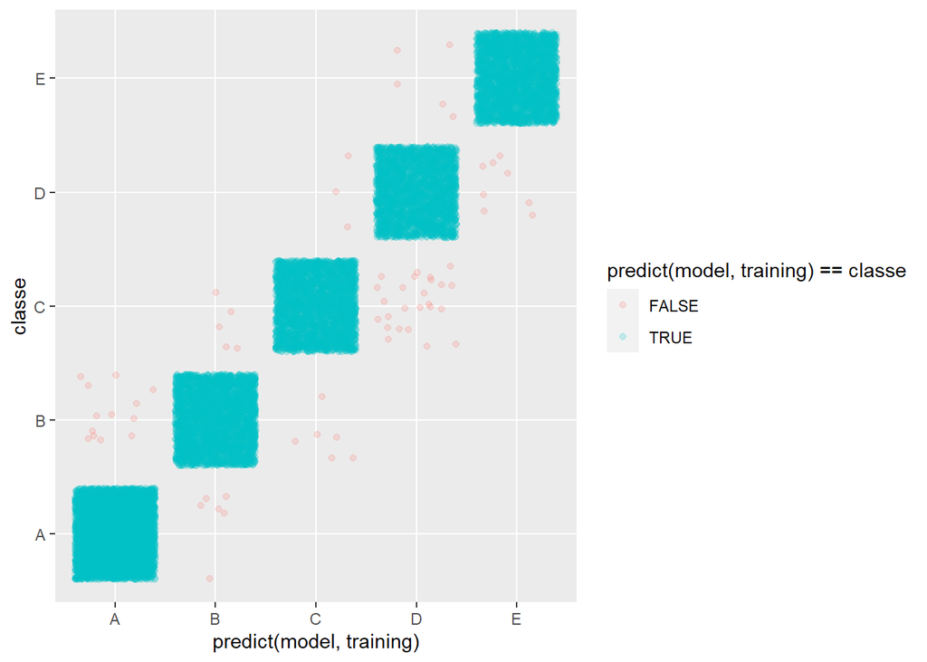

In the jitter plot shown above, the light blue points reflect accurate classifications whereas the light red points represent misclassifications. Noted in the discussion of the confusion matrix, most misclassifications appear to be between A:B and D:C (predicted:actual).